# MATH1307 Forecasting Final project

### 3.3.3 Rainfall

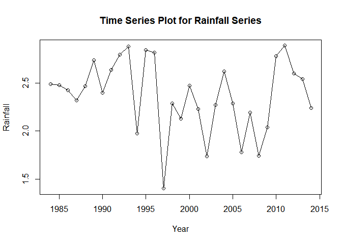

Figure 62

```r
plot(rbo.rain.ts,main="Time Series Plot for Rainfall Series",
     ylab="Rainfall",xlab="Year",type="o")
```

- The series has no apparent trends.
- There are no presence of seasonality.
- Changing variance and moving average behavior can be observed
- Intervention points can be observed in the plot at 1994 and 1997.

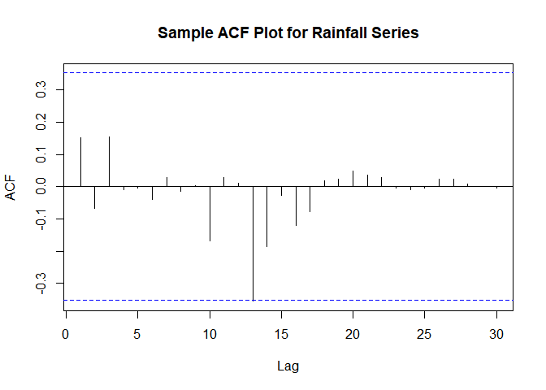

Figure 63

```r
acf(rbo.rain.ts, lag.max = 48, main="Sample ACF Plot for Rainfall Series")
```

`Figure 63` shows the sample ACF plot for rainfall series. Here we can observe that first lag is not significant which suggests stationary in series.

```r
adf.test(rbo.rain.ts, k=ar(rbo.rain.ts)$order)
```

```
##
##  Augmented Dickey-Fuller Test
##
## data:  rbo.rain.ts
## Dickey-Fuller = -4.5622, Lag order = 0, p-value = 0.01
## alternative hypothesis: stationary
```

### 3.3.4 Radiation

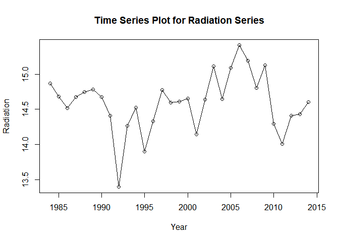

Figure 64

```r
plot(rbo.rad.ts,main="Time Series Plot for Radiation Series",
     ylab="Radiation",xlab="Year",type="o")
```

- The series has no apparent trends.
- There are no presence of seasonality.
- Changing variance and moving average behavior can be observed
- Multiple Intervention points can be observed in the plot.

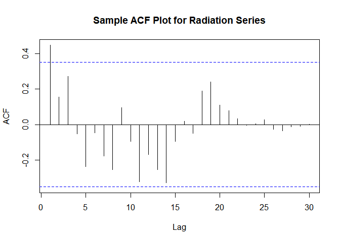

Figure 65

```r
acf(rbo.rad.ts, lag.max = 48, main="Sample ACF Plot for Radiation Series")
```

`Figure 65` shows the sample ACF plot for radiation series. Here we can observe that first lag is significant which suggests non-stationary in series.

```r
adf.test(rbo.rad.ts, k=ar(rbo.rad.ts)$order)
```

```
##
##  Augmented Dickey-Fuller Test
##
## data:  rbo.rad.ts
## Dickey-Fuller = -2.7317, Lag order = 4, p-value = 0.2911
## alternative hypothesis: stationary
```

In the above output, we used the ADF test for the radiation series. In this approach, we can conclude that the radiation series is non-stationary at 5% level of significance as p value is greater than 0.05.

### 3.3.5 Relative Humidity

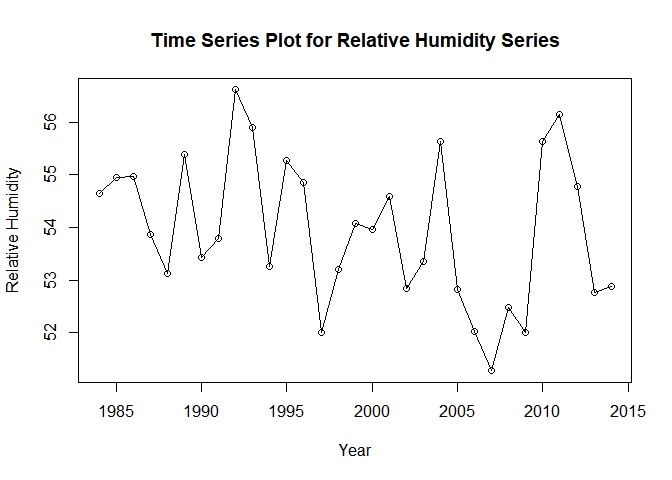

Figure 66

```r
plot(rbo.hum.ts,main="Time Series Plot for Relative Humidity Series",
     ylab="Relative Humidity",xlab="Year",type="o")
```

- The series has no apparent trends.
- There are no presence of seasonality.
- Changing variance and moving average behavior can be observed
- No intervention points can be observed in the plot.

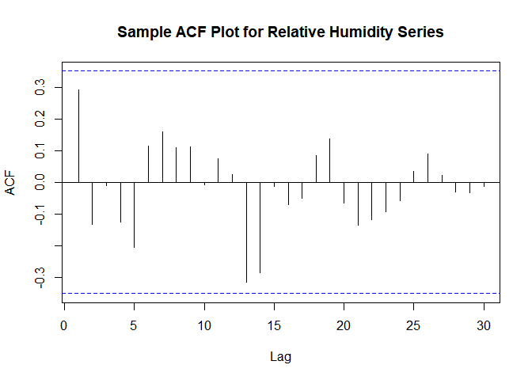

Figure 67

```r
acf(rbo.hum.ts, lag.max = 48, main="Sample ACF Plot for Relative Humidity Series")
```

`Figure 67` shows the sample ACF plot for relative humidity series. Here we can observe that first lag is not significant which suggests stationary in series.

```r
adf.test(rbo.hum.ts, k=ar(rbo.hum.ts)$order)
```

```
##
##  Augmented Dickey-Fuller Test
##
## data:  rbo.hum.ts
## Dickey-Fuller = -4.1163, Lag order = 1, p-value = 0.01789
## alternative hypothesis: stationary
```

### 3.3.6 Scaled Data Series

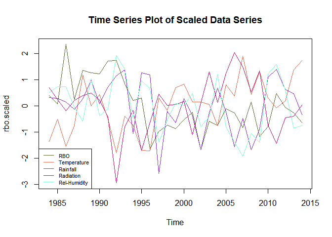

Figure 68

```r
rbo.scaled<-scale(rbo.ts)

rbo.col<-c("darkolivegreen","coral2","blueviolet","deeppink3","aquamarine")

plot(rbo.scaled,plot.type="s",col=rbo.col,main="Time Series Plot of Scaled Data Series")
legend("bottomleft",cex=0.7,lty=1,col=rbo.col,c("RBO","Temperature","Rainfall","Radiation","Rel-Humidity"))
```

`Figure 68` contains a time series plot of all the data for RBO. To compare these data and fit them in a graph, scaling and centering is done to the data by using the `scale` function.

## 3.4.0 Dealing with Non-Stationary

### 3.4.1 RBO

First we will produce the acf and pacf plot for getting a grasp of the changes made by differencing.

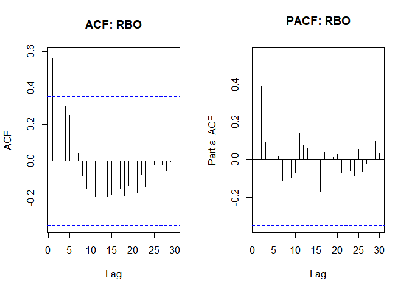

Figure 69

```r
par(mfrow=c(1,2))
acf(rbo.rbo.ts,lag.max = 48,main="ACF: RBO")
pacf(rbo.rbo.ts,lag.max = 48,main="PACF: RBO")
```

Now we will use the function `diff` to deal with non-stationary data with first difference order.

```r
rbo.rbo.diff<-diff(rbo.rbo.ts,differences=1)
adf.test(rbo.rbo.diff, k=ar(rbo.rbo.diff)$order)
```

```
##
##  Augmented Dickey-Fuller Test
##
## data:  rbo.rbo.diff
## Dickey-Fuller = -6.0473, Lag order = 1, p-value = 0.01
## alternative hypothesis: stationary
```

In the adf output above, we can conclude that the RBO series is now stationary at 5% level of significance as p value is less than 0.05. So we can now plot the acf and pacf plot of the differenced RBO data.

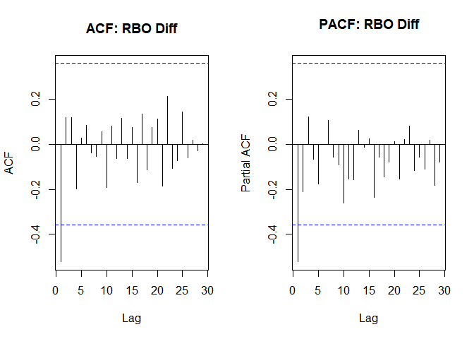

Figure 70

```r
par(mfrow=c(1,2))
acf(rbo.rbo.diff,lag.max = 48,main="ACF: RBO Diff")
pacf(rbo.rbo.diff,lag.max = 48,main="PACF: RBO Diff")
```

### 3.4.2 Temperature

First we will produce the acf and pacf plot for getting a grasp of the changes made by differencing.

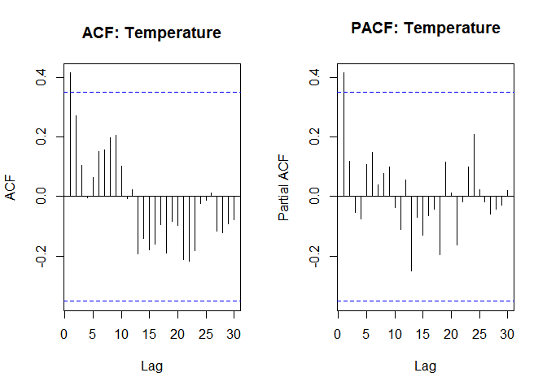

Figure 71

```r
par(mfrow=c(1,2))
acf(rbo.temp.ts,lag.max = 48,main="ACF: Temperature")
pacf(rbo.temp.ts,lag.max = 48,main="PACF: Temperature")
```

Now we will use the function `diff` to deal with non-stationary data with first difference order.

```r
rbo.temp.diff<-diff(rbo.temp.ts,differences=1)
adf.test(rbo.temp.diff, k=ar(rbo.temp.diff)$order)
```

```
##
##  Augmented Dickey-Fuller Test
##
## data:  rbo.temp.diff
## Dickey-Fuller = -4.6021, Lag order = 1, p-value = 0.01
## alternative hypothesis: stationary
```

In the adf output above, we can conclude that the Temperature series is now stationary at 5% level of significance as p value is less than 0.05. So we can now plot the acf and pacf plot of the differenced Temperature data.

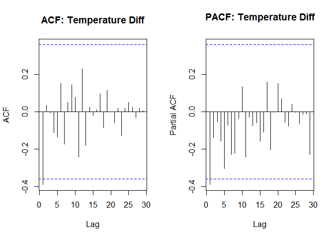

Figure 72

```r
par(mfrow=c(1,2))
acf(rbo.temp.diff,lag.max = 48,main="ACF: Temperature Diff")
pacf(rbo.temp.diff,lag.max = 48,main="PACF: Temperature Diff")
```

### 3.4.3 Radiation

First we will produce the acf and pacf plot for getting a grasp of the changes made by differencing.

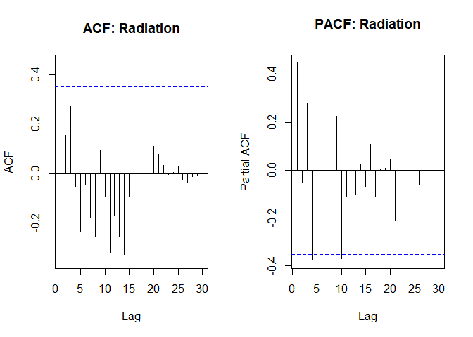

Figure 73

```r
par(mfrow=c(1,2))
acf(rbo.rad.ts,lag.max = 48,main="ACF: Radiation")
pacf(rbo.rad.ts,lag.max = 48,main="PACF: Radiation")
```

Now we will use the function `diff` to deal with non-stationary data with second difference order.

```r
rbo.rad.diff<-diff(rbo.rad.ts,differences=2)
adf.test(rbo.rad.diff, k=ar(rbo.rad.diff)$order)
```

```
##
##  Augmented Dickey-Fuller Test
##
## data:  rbo.rad.diff
## Dickey-Fuller = -4.7561, Lag order = 2, p-value = 0.01
## alternative hypothesis: stationary
```

In the adf output above, we can conclude that the Radiation series is now stationary at 5% level of significance as p value is less than 0.05. So we can now plot the acf and pacf plot of the differenced Radiation data.

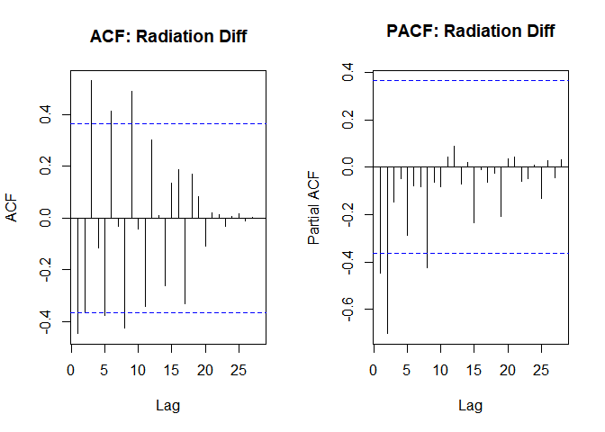

Figure 74

```r
par(mfrow=c(1,2))
acf(rbo.rad.diff,lag.max = 48,main="ACF: Radiation Diff")
pacf(rbo.rad.diff,lag.max = 48,main="PACF: Radiation Diff")
```

With the differencing operation, we are successful in dealing with the non-stationary data by using order differences 1, 1, and 2 for RBO, temperature, and radiation series.

## 3.5.0 Correlation

In this section, we will look at the correlation matrix for the data set by using the `cor` function.

```r
cor(rbo.ts)
```

```
##                    RBO Temperature   Rainfall  Radiation RelHumidity
## RBO          1.0000000  -0.3452053  0.3932282 -0.3173602   0.3885540
## Temperature -0.3452053   1.0000000 -0.3915072  0.5193576  -0.6621980
## Rainfall     0.3932282  -0.3915072  1.0000000 -0.5813161   0.7911079
## Radiation   -0.3173602   0.5193576 -0.5813161  1.0000000  -0.7354087
## RelHumidity  0.3885540  -0.6621980  0.7911079 -0.7354087   1.0000000
```

From the correlation output above, we can see that for RBO, there is a low negative correlation with Temperature of -0.3452053, low positive correlation with Rainfall of 0.3932282, low negative correlation with Radiation of -0.3173602, and low positive correlation with Relative Humidity of 0.3885540. Since we will be analyzing RBO, we shall use RBO as the dependent variable y and the rest of the variables in the series as independent variable x. To further perform univariate analysis of predictors, we shall test each variable with every models and compare mase values to find the best model.

## 3.6.0 Time Series Regression Models

### 3.6.1 Finite Distributed Lag Model

For Finite DLM, we will be using temperature as the independent variable, and the RBO will be the dependent variable. To perform this test, we will first create a loop function and use the `dlm` function to identify most appropriate number of lags for the DLM.

```r
for (i in 10){
model1<-dlm(x=as.vector(rbo.temp.ts), y=as.vector(rbo.rbo.ts), q=i)
cat("q =",i,"AIC =",AIC(model1$model),"BIC =",BIC(model1$model),"MASE=", MASE(model1)$MASE,
"\n")
}
```

```
## q = 10 AIC = -85.18937 BIC = -71.61058 MASE= 0.523527
```

From the loop function above we will use q=10 as our argument for lag length in the analysis of other variables. Now we will use the `dlm` function to fit the finite dlm for other predictors, and we will compare the aic, bic, and mase values for each predictors.

```r
#RBO & Temperature
model1.1<-dlm(x=as.vector(rbo.temp.ts),y=as.vector(rbo.rbo.ts),q=10)
#RBO & Rainfall
model1.2<-dlm(x=as.vector(rbo.rain.ts),y=as.vector(rbo.rbo.ts),q=10)
#RBO & Radiation
model1.3<-dlm(x=as.vector(rbo.rad.ts),y=as.vector(rbo.rbo.ts),q=10)
#RBO & Relative Humidity
model1.4<-dlm(x=as.vector(rbo.hum.ts),y=as.vector(rbo.rbo.ts),q=10)
#Compare
predictor<-c("Temperature","Rainfall","Radiation","Relative Humidity")
fdlm.mase<-MASE(model1.1,model1.2,model1.3,model1.4)
fdlm.aic<-c(AIC(model1.1),AIC(model1.2),AIC(model1.3),AIC(model1.4))
```

```
## [1] -85.18937
## [1] -76.93255
## [1] -78.06879
## [1] -77.84443
```

```r
fdlm.bic<-c(BIC(model1.1),BIC(model1.2),BIC(model1.3),BIC(model1.4))
```

```
## [1] -71.61058
## [1] -63.35376
## [1] -64.49
## [1] -64.26564
```

```r
fdlm<-data.frame(predictor,fdlm.mase,fdlm.aic,fdlm.bic)
arrange(fdlm,MASE)
```

```
##                  predictor  n      MASE  fdlm.aic  fdlm.bic
## model1.1       Temperature 21 0.5235270 -85.18937 -71.61058
## model1.2          Rainfall 21 0.5856170 -76.93255 -63.35376
## model1.4 Relative Humidity 21 0.5947606 -77.84443 -64.26564
## model1.3         Radiation 21 0.6037290 -78.06879 -64.49000
```

From the predictor comparison output above we can see that `model1.1` for predictor RBO and Temperature has the lowest AIC, BIC, and MASE values, hence we shall select this predictor for further analysis.

```r
summary(model1.1)
```

```
##
## Call:
## lm(formula = model.formula, data = design)
##
## Residuals:
##      Min       1Q   Median       3Q      Max
## -0.02910 -0.01175 -0.00495  0.01596  0.02903
##
## Coefficients:
##              Estimate Std. Error t value Pr(>|t|)
## (Intercept)  0.301149   0.398691   0.755    0.469
## x.t         -0.011599   0.012936  -0.897    0.393
## x.1          0.024259   0.013847   1.752    0.114
## x.2         -0.007121   0.012630  -0.564    0.587
## x.3         -0.010736   0.012412  -0.865    0.410
## x.4          0.010868   0.012314   0.883    0.400
## x.5         -0.001881   0.012441  -0.151    0.883
## x.6          0.022337   0.012282   1.819    0.102
## x.7          0.001619   0.011577   0.140    0.892
## x.8         -0.006598   0.011773  -0.560    0.589
## x.9         -0.007787   0.012477  -0.624    0.548
## x.10         0.007677   0.012192   0.630    0.545
##
## Residual standard error: 0.02618 on 9 degrees of freedom
## Multiple R-squared:  0.5452, Adjusted R-squared:  -0.0107
## F-statistic: 0.9808 on 11 and 9 DF,  p-value: 0.5205
##
## AIC and BIC values for the model:
##         AIC       BIC
## 1 -85.18937 -71.61058
```

By using the `summary` function, we can observe that in `model1.1` the lag weights of the predictors are not significant at the 5% statistical level as p-value > 0.05. Furthermore, there is a adjusted R-square value of -0.0107, which accounts for -1.07% of the variability in the data. Here we can also see that for the lags, positive lag coefficients show that higher RBO values indicate similarity of the order of the first flowering occurence. First lag indicates that flowering is not similar as x.1=0.024259, which is small value.

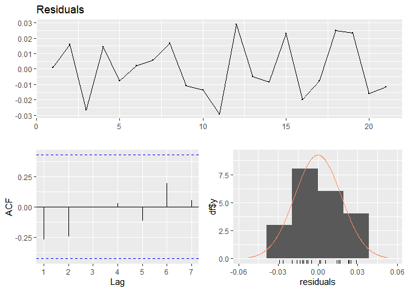

Figure 75

```
##
##  Ljung-Box test
##
## data:  Residuals
## Q* = 3.358, df = 4, p-value = 0.4998
##
## Model df: 0.   Total lags used: 4
```

```r
checkresiduals(model1.1$model$residuals)
```

```r
bgtest(model1.1$model)
```

```
##
##  Breusch-Godfrey test for serial correlation of order up to 1
##
## data:  model1.1$model
## LM test = 1.677, df = 1, p-value = 0.1953
```

```r
shapiro.test(model1.1$model$residuals)
```

```
##
##  Shapiro-Wilk normality test
##
## data:  model1.1$model$residuals
## W = 0.94816, p-value = 0.3143
```

```r
VIF.model1.1<-vif(model1.1$model)
VIF.model1.1
```

```
##      x.t      x.1      x.2      x.3      x.4      x.5      x.6      x.7
## 1.882817 1.925625 1.781877 1.739787 1.730817 1.757883 1.682573 1.517274
##      x.8      x.9     x.10
## 1.373584 1.508769 1.414382
```

```r
VIF.model1.1>10
```

```
##   x.t   x.1   x.2   x.3   x.4   x.5   x.6   x.7   x.8   x.9  x.10
## FALSE FALSE FALSE FALSE FALSE FALSE FALSE FALSE FALSE FALSE FALSE
```

### 3.6.2 Polynomial Distributed Lag Models

Similar to the finite DLM, we shall compare each predictor with the polynomial dlm and select the best with lowest aic, bic, and mase values.

```r
#RBO & Temperature
model2.1<-polyDlm(x=as.vector(rbo.temp.ts),y=as.vector(rbo.rbo.ts),q=10,k=2)
```

```
## Estimates and t-tests for beta coefficients:
##          Estimate Std. Error t value P(>|t|)
## beta.0  -0.003340    0.00592 -0.5640   0.584
## beta.1  -0.000509    0.00394 -0.1290   0.900
## beta.2   0.001700    0.00282  0.6030   0.559
## beta.3   0.003290    0.00260  1.2600   0.232
## beta.4   0.004270    0.00285  1.5000   0.163
## beta.5   0.004630    0.00310  1.4900   0.164
## beta.6   0.004370    0.00322  1.3500   0.203
## beta.7   0.003490    0.00332  1.0500   0.316
## beta.8   0.001990    0.00372  0.5360   0.602
## beta.9  -0.000120    0.00473 -0.0253   0.980
## beta.10 -0.002850    0.00647 -0.4400   0.668
```

```r
#RBO & Rainfall
model2.2<-polyDlm(x=as.vector(rbo.rain.ts),y=as.vector(rbo.rbo.ts),q=10,k=2)
```

```
## Estimates and t-tests for beta coefficients:
##          Estimate Std. Error t value P(>|t|)
## beta.0   0.015300    0.01110   1.380   0.196
## beta.1   0.009620    0.00737   1.310   0.218
## beta.2   0.004830    0.00576   0.839   0.419
## beta.3   0.000907    0.00580   0.156   0.879
## beta.4  -0.002160    0.00618  -0.349   0.734
## beta.5  -0.004360    0.00611  -0.712   0.491
## beta.6  -0.005690    0.00546  -1.040   0.320
## beta.7  -0.006170    0.00474  -1.300   0.220
## beta.8  -0.005780    0.00549  -1.050   0.315
## beta.9  -0.004520    0.00872  -0.519   0.614
## beta.10 -0.002410    0.01380  -0.174   0.865
```

```r
#RBO & Radiation
model2.3<-polyDlm(x=as.vector(rbo.rad.ts),y=as.vector(rbo.rbo.ts),q=10,k=2)
```

```
## Estimates and t-tests for beta coefficients:
##          Estimate Std. Error t value P(>|t|)
## beta.0  -0.005740    0.00831  -0.691   0.504
## beta.1  -0.002240    0.00532  -0.422   0.681
## beta.2   0.000648    0.00369   0.176   0.864
## beta.3   0.002930    0.00346   0.847   0.415
## beta.4   0.004600    0.00377   1.220   0.248
## beta.5   0.005650    0.00389   1.450   0.174
## beta.6   0.006100    0.00367   1.660   0.125
## beta.7   0.005940    0.00345   1.720   0.113
## beta.8   0.005160    0.00413   1.250   0.237
## beta.9   0.003780    0.00628   0.601   0.560
## beta.10  0.001780    0.00968   0.184   0.857
```

```r
#RBO & Relative Humidity
model2.4<-polyDlm(x=as.vector(rbo.hum.ts),y=as.vector(rbo.rbo.ts),q=10,k=2)
```

```
## Estimates and t-tests for beta coefficients:
##          Estimate Std. Error  t value P(>|t|)
## beta.0   3.57e-03    0.00263  1.36000   0.201
## beta.1   2.22e-03    0.00200  1.11000   0.290
## beta.2   1.03e-03    0.00173  0.59900   0.562
## beta.3   1.63e-05    0.00168  0.00969   0.992
## beta.4  -8.36e-04    0.00166 -0.50400   0.625
## beta.5  -1.52e-03    0.00159 -0.96000   0.358
## beta.6  -2.04e-03    0.00148 -1.38000   0.195
## beta.7  -2.39e-03    0.00150 -1.59000   0.139
## beta.8  -2.58e-03    0.00190 -1.36000   0.202
## beta.9  -2.60e-03    0.00275 -0.94500   0.365
## beta.10 -2.46e-03    0.00397 -0.61800   0.549
```

```r
#Compare
predictor<-c("Temperature","Rainfall","Radiation","Relative Humidity")
pdlm.mase<-MASE(model2.1,model2.2,model2.3,model2.4)
pdlm.aic<-c(AIC(model2.1),AIC(model2.2),AIC(model2.3),AIC(model2.4))
```

```
## [1] -87.29374
## [1] -88.26525
## [1] -88.15084
## [1] -88.49321
```

```r
pdlm.bic<-c(BIC(model2.1),BIC(model2.2),BIC(model2.3),BIC(model2.4))
```

```
## [1] -82.07113
## [1] -83.04264
## [1] -82.92823
## [1] -83.2706
```

```r
pdlm<-data.frame(predictor,pdlm.mase,pdlm.aic,pdlm.bic)
arrange(pdlm,MASE)
```

```
##                  predictor  n      MASE  pdlm.aic  pdlm.bic
## model2.2          Rainfall 21 0.6451804 -88.26525 -83.04264
## model2.4 Relative Humidity 21 0.6523137 -88.49321 -83.27060
## model2.3         Radiation 21 0.6711964 -88.15084 -82.92823
## model2.1       Temperature 21 0.6714874 -87.29374 -82.07113
```

```r
summary(model2.2)
```

```
##
## Call:
## "Y ~ (Intercept) + X.t"
##
## Residuals:
##       Min        1Q    Median        3Q       Max
## -0.056127 -0.014819  0.002352  0.012277  0.038053
##
## Coefficients:
##               Estimate Std. Error t value Pr(>|t|)
## (Intercept)  0.7166742  0.1029308   6.963 2.29e-06 ***
## z.t0         0.0152725  0.0110859   1.378    0.186
## z.t1        -0.0060829  0.0055819  -1.090    0.291
## z.t2         0.0004315  0.0005823   0.741    0.469
## ---
## Signif. codes:  0 '***' 0.001 '**' 0.01 '*' 0.05 '.' 0.1 ' ' 1
##
## Residual standard error: 0.02592 on 17 degrees of freedom
## Multiple R-squared:  0.1584, Adjusted R-squared:  0.009865
## F-statistic: 1.066 on 3 and 17 DF,  p-value: 0.3894
```

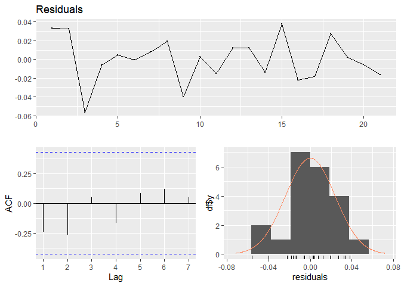

Figure 76

```
##
##  Ljung-Box test
##
## data:  Residuals
## Q* = 4.0189, df = 4, p-value = 0.4035
##
## Model df: 0.   Total lags used: 4
```

```r
checkresiduals(model2.2$model$residuals)
```

```r
bgtest(model2.2$model)
```

```
##
##  Breusch-Godfrey test for serial correlation of order up to 1
##
## data:  model2.2$model
## LM test = 1.2962, df = 1, p-value = 0.2549
```

```r
shapiro.test(model2.2$model$residuals)
```

```
##
##  Shapiro-Wilk normality test
##
## data:  model2.2$model$residuals
## W = 0.97008, p-value = 0.7348
```

```r
VIF.model2.2<-vif(model2.2$model)
VIF.model2.2
```

```
##      z.t0      z.t1      z.t2
##  8.346588 77.158308 47.720427
```

```r
VIF.model2.2>10
```

```
##  z.t0  z.t1  z.t2
## FALSE  TRUE  TRUE
```

In the output shown above, which is the test for multicollinearity by using the variance inflation factors (VIF) using the vif function, we can observe that there is issue with multicollinearity as VIF values z.t1 and z.t2 are greater than 10.

### 3.6.3 Koyck Distributed Lag Model

Similar to the previous models, we shall compare each predictor with the Koyck dlm and select the best in terms of aic, bic, and mase values.

```r
#FFD & Temperature
model3.1<-koyckDlm(x=as.vector(rbo.temp.ts),y=as.vector(rbo.rbo.ts))
#FFD & Rainfall
model3.2<-koyckDlm(x=as.vector(rbo.rain.ts),y=as.vector(rbo.rbo.ts))
#FFD & Radiation
model3.3<-koyckDlm(x=as.vector(rbo.rad.ts),y=as.vector(rbo.rbo.ts))
#FFD & Relative Humidity
model3.4<-koyckDlm(x=as.vector(rbo.hum.ts),y=as.vector(rbo.rbo.ts))
#Compare
predictor<-c("Temperature","Rainfall","Radiation","Relative Humidity")
kdlm.mase<-MASE(model3.1,model3.2,model3.3,model3.4)
kdlm.aic<-c(AIC(model3.1),AIC(model3.2),AIC(model3.3),AIC(model3.4))
```

```
## [1] -98.54907
## [1] 76.22068
## [1] -93.8669
## [1] -106.3136
```

```r
kdlm.bic<-c(BIC(model3.1),BIC(model3.2),BIC(model3.3),BIC(model3.4))
```

```
## [1] -92.94428
## [1] 81.82547
## [1] -88.26211
## [1] -100.7088
```

```r
kdlm<-data.frame(predictor,kdlm.mase,kdlm.aic,kdlm.bic)
arrange(kdlm,MASE)
```

```
##                  predictor  n       MASE   kdlm.aic   kdlm.bic
## model3.4 Relative Humidity 30  0.8400135 -106.31363 -100.70884
## model3.1       Temperature 30  0.9535116  -98.54907  -92.94428
## model3.3         Radiation 30  1.0314227  -93.86690  -88.26211
## model3.2          Rainfall 30 19.1057647   76.22068   81.82547
```

From the output above, we can see that predictor Relative Humidity is the best choice as it has the lowest MASE, AIC, and BIC values. Hence we will use this predictor for further analysis.

```r
summary(model3.4)
```

```
##
## Call:
## "Y ~ (Intercept) + Y.1 + X.t"
##
## Residuals:
##       Min        1Q    Median        3Q       Max
## -0.081436 -0.017779 -0.005166  0.019919  0.101789
##
## Coefficients:
##             Estimate Std. Error t value Pr(>|t|)
## (Intercept) 0.215367   1.204579   0.179   0.8594
## Y.1         0.548465   0.290591   1.887   0.0699 .
## X.t         0.002164   0.025588   0.085   0.9332
## ---
## Signif. codes:  0 '***' 0.001 '**' 0.01 '*' 0.05 '.' 0.1 ' ' 1
##
## Residual standard error: 0.03795 on 27 degrees of freedom
## Multiple R-Squared: 0.3452,  Adjusted R-squared: 0.2967
## Wald test:  6.62 on 2 and 27 DF,  p-value: 0.004576
##
## Diagnostic tests:
## NULL
##
##                              alpha        beta       phi
## Geometric coefficients:  0.4769667 0.002164239 0.5484653
```

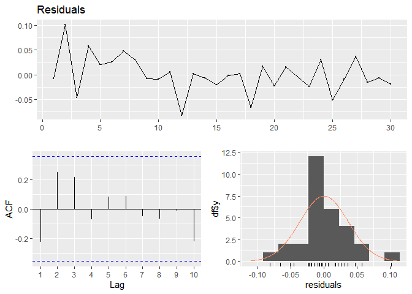

Figure 77

```
##
##  Ljung-Box test
##
## data:  Residuals
## Q* = 6.2549, df = 6, p-value = 0.3952
##
## Model df: 0.   Total lags used: 6
```

```r
checkresiduals(model3.4$model$residuals)
```

```r
bgtest(model3.4$model)
```

```
##
##  Breusch-Godfrey test for serial correlation of order up to 1
##
## data:  model3.4$model
## LM test = 3.6165, df = 1, p-value = 0.05721
```

```r
shapiro.test(model3.4$model$residuals)
```

```
##
##  Shapiro-Wilk normality test
##
## data:  model3.4$model$residuals
## W = 0.96587, p-value = 0.4332
```

```r
VIF.model3.4<-vif(model3.4$model)
VIF.model3.4
```

```
##      Y.1      X.t
## 3.449396 3.449396
```

```r
VIF.model3.4>10
```

```
##   Y.1   X.t
## FALSE FALSE
```

In the output shown above, which is the test for multicollinearity by using the variance inflation factors (VIF) using the vif function, we can observe that there no issue with multicollinearity as VIF values are all less than 10.

### 3.6.4 Autoregressive Distributed Lag Model

Similar to previous models, we will compare and find the best fit and predictors based on the aic, bic, and mase values. To perform the Autoregressive DLM, we will first create a loop function for p and q and use the `ardlDLM` function to identify the most appropriate number of lags for the DLM.

```r
for (i in 1:5){
for(j in 1:5){
  model4.1 = ardlDlm(x = as.vector(rbo.temp.ts), y = as.vector(rbo.rbo.ts), p = i ,
                     q = j)
  cat("p =", i, "q =", j, "AIC =", AIC(model4.1$model), "BIC =",
      BIC(model4.1$model), "MASE =",
      MASE(model4.1)$MASE, "\n")

  }
}
```

```
## p = 1 q = 1 AIC = -105.6323 BIC = -98.62635 MASE = 0.8183474
## p = 1 q = 2 AIC = -106.7338 BIC = -98.53007 MASE = 0.7421788
## p = 1 q = 3 AIC = -109.2081 BIC = -99.88269 MASE = 0.7734247
## p = 1 q = 4 AIC = -102.1791 BIC = -91.81242 MASE = 0.8236063
## p = 1 q = 5 AIC = -97.33529 BIC = -86.01242 MASE = 0.7402468
## p = 2 q = 1 AIC = -100.7618 BIC = -92.55807 MASE = 0.9167429
## p = 2 q = 2 AIC = -105.1274 BIC = -95.55629 MASE = 0.7379592
## p = 2 q = 3 AIC = -107.2334 BIC = -96.57577 MASE = 0.7724694
## p = 2 q = 4 AIC = -100.1907 BIC = -88.52822 MASE = 0.8207833
## p = 2 q = 5 AIC = -95.74261 BIC = -83.16164 MASE = 0.7353386
## p = 3 q = 1 AIC = -101.7805 BIC = -92.45505 MASE = 0.9406755
## p = 3 q = 2 AIC = -107.3386 BIC = -96.681 MASE = 0.7740433
## p = 3 q = 3 AIC = -105.3553 BIC = -93.36549 MASE = 0.7735463
## p = 3 q = 4 AIC = -98.69016 BIC = -85.73179 MASE = 0.8250965
## p = 3 q = 5 AIC = -94.15321 BIC = -80.31415 MASE = 0.7628024
## p = 4 q = 1 AIC = -96.62629 BIC = -86.25959 MASE = 0.9476737
## p = 4 q = 2 AIC = -100.9245 BIC = -89.26198 MASE = 0.8489344
## p = 4 q = 3 AIC = -99.22742 BIC = -86.26905 MASE = 0.8460958
## p = 4 q = 4 AIC = -97.42765 BIC = -83.17345 MASE = 0.8471965
## p = 4 q = 5 AIC = -95.44763 BIC = -80.35047 MASE = 0.778824
## p = 5 q = 1 AIC = -96.37589 BIC = -85.05302 MASE = 0.7857653
## p = 5 q = 2 AIC = -97.48107 BIC = -84.90011 MASE = 0.756288
## p = 5 q = 3 AIC = -95.70698 BIC = -81.86792 MASE = 0.7620542
## p = 5 q = 4 AIC = -93.77188 BIC = -78.67472 MASE = 0.7576551
## p = 5 q = 5 AIC = -93.93583 BIC = -77.58057 MASE = 0.7335979
```

```r
#P=1 Q=5
#RBO & Temperature
model4.2.1<-ardlDlm(x=as.vector(rbo.temp.ts),y=as.vector(rbo.rbo.ts),p=1,q=5)
#RBO & Rainfall
model4.2.2<-ardlDlm(x=as.vector(rbo.rain.ts),y=as.vector(rbo.rbo.ts),p=1,q=5)
#RBO & Radiation
model4.2.3<-ardlDlm(x=as.vector(rbo.rad.ts),y=as.vector(rbo.rbo.ts),p=1,q=5)
#RBO & Relative Humidity
model4.2.4<-ardlDlm(x=as.vector(rbo.hum.ts),y=as.vector(rbo.rbo.ts),p=1,q=5)

#P=1 Q=3
#RBO & Temperature
model4.3.1<-ardlDlm(x=as.vector(rbo.temp.ts),y=as.vector(rbo.rbo.ts),p=1,q=3)
#RBO & Rainfall
model4.3.2<-ardlDlm(x=as.vector(rbo.rain.ts),y=as.vector(rbo.rbo.ts),p=1,q=3)
#RBO & Radiation
model4.3.3<-ardlDlm(x=as.vector(rbo.rad.ts),y=as.vector(rbo.rbo.ts),p=1,q=3)
#RBO & Relative Humidity
model4.3.4<-ardlDlm(x=as.vector(rbo.hum.ts),y=as.vector(rbo.rbo.ts),p=1,q=3)

#P=5 Q=5
#RBO & Temperature
model4.4.1<-ardlDlm(x=as.vector(rbo.temp.ts),y=as.vector(rbo.rbo.ts),p=5,q=5)
#RBO & Rainfall
model4.4.2<-ardlDlm(x=as.vector(rbo.rain.ts),y=as.vector(rbo.rbo.ts),p=5,q=5)
#RBO & Radiation
model4.4.3<-ardlDlm(x=as.vector(rbo.rad.ts),y=as.vector(rbo.rbo.ts),p=5,q=5)
#RBO & Relative Humidity
model4.4.4<-ardlDlm(x=as.vector(rbo.hum.ts),y=as.vector(rbo.rbo.ts),p=5,q=5)

predictor<-c("Temperature","Rainfall","Radiation","Relative Humidity")
adlm.mase1<-MASE(model4.2.1,model4.2.2,model4.2.3,model4.2.4)
adlm.aic1<-c(AIC(model4.2.1),AIC(model4.2.2),AIC(model4.2.3),AIC(model4.2.4))
```

```
## [1] -97.33529
## [1] -95.80256
## [1] -100.2033
## [1] -97.27466
```

```r
adlm.bic1<-c(BIC(model4.2.1),BIC(model4.2.2),BIC(model4.2.3),BIC(model4.2.4))
```

```
## [1] -86.01242
## [1] -84.47969
## [1] -88.88038
## [1] -85.95179
```

```r
adlm1<-data.frame(predictor,adlm.mase1,adlm.aic1,adlm.bic1)
colnames(adlm1)<-c("predictor","n","MASE","AIC","BIC")

adlm.mase2<-MASE(model4.3.1,model4.3.2,model4.3.3,model4.3.4)
adlm.aic2<-c(AIC(model4.3.1),AIC(model4.3.2),AIC(model4.3.3),AIC(model4.3.4))
```

```
## [1] -109.2081
## [1] -106.9248
## [1] -110.6338
## [1] -108.3405
```

```r
adlm.bic2<-c(BIC(model4.3.1),BIC(model4.3.2),BIC(model4.3.3),BIC(model4.3.4))
```

```
## [1] -99.88269
## [1] -97.59935
## [1] -101.3084
## [1] -99.01504
```

```r
adlm2<-data.frame(predictor,adlm.mase2,adlm.aic2,adlm.bic2)
colnames(adlm2)<-c("predictor","n","MASE","AIC","BIC")

adlm.mase3<-MASE(model4.4.1,model4.4.2,model4.4.3,model4.4.4)
adlm.aic3<-c(AIC(model4.4.1),AIC(model4.4.2),AIC(model4.4.3),AIC(model4.4.4))
```

```
## [1] -93.93583
## [1] -90.68282
## [1] -93.6481
## [1] -92.45536
```

```r
adlm.bic3<-c(BIC(model4.4.1),BIC(model4.4.2),BIC(model4.4.3),BIC(model4.4.4))
```

```
## [1] -77.58057
## [1] -74.32757
## [1] -77.29285
## [1] -76.1001
```

```r
adlm3<-data.frame(predictor,adlm.mase3,adlm.aic3,adlm.bic3)
colnames(adlm3)<-c("predictor","n","MASE","AIC","BIC")

adlm4<-rbind(adlm1,adlm2,adlm3)
arrange(adlm4,MASE)
```

```
##                    predictor  n      MASE        AIC        BIC
## model4.4.3         Radiation 26 0.7145698  -93.64810  -77.29285
## model4.4.1       Temperature 26 0.7335979  -93.93583  -77.58057
## model4.4.4 Relative Humidity 26 0.7370787  -92.45536  -76.10010
## model4.2.1       Temperature 26 0.7402468  -97.33529  -86.01242
## model4.4.2          Rainfall 26 0.7469974  -90.68282  -74.32757
## model4.2.3         Radiation 26 0.7627672 -100.20325  -88.88038
## model4.3.1       Temperature 28 0.7734247 -109.20812  -99.88269
## model4.2.4 Relative Humidity 26 0.7813433  -97.27466  -85.95179
## model4.2.2          Rainfall 26 0.8152025  -95.80256  -84.47969
## model4.3.4 Relative Humidity 28 0.8196903 -108.34047  -99.01504
## model4.3.3         Radiation 28 0.8202653 -110.63384 -101.30840
## model4.3.2          Rainfall 28 0.8322089 -106.92478  -97.59935
```

In the output above, we can observe that `model4.4.3` which is radiation predictor (P5 Q5) has the lowest MASE values, `model4.3.3`, radiation predictor (P1 Q3) has the lowest AIC values, and BIC values. In our case, we will select `model4.4.3` as it has the lowest MASE values for further analysis.

```r
summary(model4.4.3)
```

```
##
## Time series regression with "ts" data:
## Start = 6, End = 31
##
## Call:
## dynlm(formula = as.formula(model.text), data = data, start = 1)
##
## Residuals:
##       Min        1Q    Median        3Q       Max
## -0.058181 -0.010561  0.005937  0.011888  0.039893
##
## Coefficients:
##              Estimate Std. Error t value Pr(>|t|)
## (Intercept) -0.235092   0.635369  -0.370   0.7169
## X.t         -0.025859   0.020766  -1.245   0.2335
## X.1          0.026744   0.023598   1.133   0.2761
## X.2          0.008284   0.023664   0.350   0.7315
## X.3          0.006908   0.023343   0.296   0.7716
## X.4          0.004317   0.024792   0.174   0.8643
## X.5          0.006035   0.022186   0.272   0.7896
## Y.1          0.456956   0.259256   1.763   0.0998 .
## Y.2          0.235367   0.266174   0.884   0.3915
## Y.3          0.101679   0.243130   0.418   0.6821
## Y.4         -0.176699   0.222300  -0.795   0.4400
## Y.5          0.170775   0.240520   0.710   0.4893
## ---
## Signif. codes:  0 '***' 0.001 '**' 0.01 '*' 0.05 '.' 0.1 ' ' 1
##
## Residual standard error: 0.03303 on 14 degrees of freedom
## Multiple R-squared:  0.6466, Adjusted R-squared:  0.3689
## F-statistic: 2.328 on 11 and 14 DF,  p-value: 0.06941
```

By using the `summary` function, we can observe that in `model4.4.3` the lag weights of the predictors are not significant at the 5% statistical level as p-value > 0.05. Furthermore, there is a adjusted R-square value of 0.3689, which accounts for 36.89% of the variability in the data. Here we can also see that for the lags, positive lag coefficients show that higher RBO values indicate similarity of the order of the first flowering occurrence. First lag indicates that flowering is not similar as X.1=0..026744.

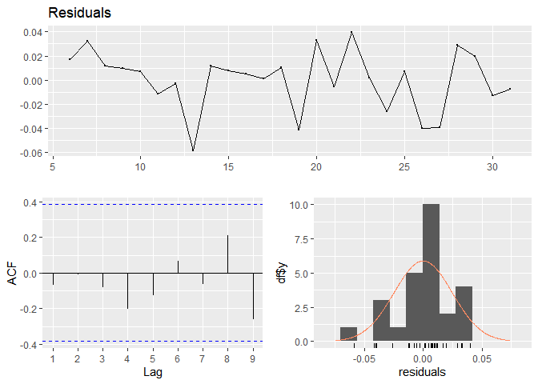

Figure 78

```
##
##  Ljung-Box test
##
## data:  Residuals
## Q* = 2.236, df = 5, p-value = 0.8156
##
## Model df: 0.   Total lags used: 5
```

```r
checkresiduals(model4.4.3$model$residuals)
```

```r
bgtest(model4.4.3$model)
```

```
##
##  Breusch-Godfrey test for serial correlation of order up to 1
##
## data:  model4.4.3$model
## LM test = 1.6982, df = 1, p-value = 0.1925
```

```r
shapiro.test(model4.4.3$model$residuals)
```

```
##
##  Shapiro-Wilk normality test
##
## data:  model4.4.3$model$residuals
## W = 0.94347, p-value = 0.1625
```

```r
VIF.model4.4.3<-vif(model4.4.3$model)
VIF.model4.4.3
```

```
##       X.t L(X.t, 1) L(X.t, 2) L(X.t, 3) L(X.t, 4) L(X.t, 5) L(y.t, 1) L(y.t, 2)
##  1.884005  2.448098  2.454577  2.374717  2.484701  1.966329  2.901087  3.066142
## L(y.t, 3) L(y.t, 4) L(y.t, 5)
##  3.162682  2.626466  3.015791
```

```r
VIF.model4.4.3>10
```

```
##       X.t L(X.t, 1) L(X.t, 2) L(X.t, 3) L(X.t, 4) L(X.t, 5) L(y.t, 1) L(y.t, 2)
##     FALSE     FALSE     FALSE     FALSE     FALSE     FALSE     FALSE     FALSE
## L(y.t, 3) L(y.t, 4) L(y.t, 5)
##     FALSE     FALSE     FALSE
```

In the output shown above, which is the test for multicollinearity by using the variance inflation factors (VIF) using the vif function, we can observe that there no issue with multicollinearity as VIF values are all less than 10.

## 3.7.0 Dynamic Lag Models

We will fit the dynamic linear models as the model is for assessing the effect of the intervention on the time series. We will compute the following dynamic lag models and choose the best one with the lowest mase value for further analysis.

```r
Y.t=log(rbo.rbo.ts)
T=3
P.t=1*(seq(rbo.rbo.ts)==T)
P.t.1=Lag(P.t,+1)

model5.1 = dynlm(Y.t ~ L(Y.t , k = 1 ) + P.t.1 + P.t + trend(Y.t))
model5.2 = dynlm(Y.t ~ L(Y.t , k = 1 ) + P.t.1 + P.t + L(Y.t , k = 2 )
                 + trend(Y.t))

model5.mase<-MASE(lm(model5.1),lm(model5.2))
arrange(model5.mase,MASE)
```

```
##               n      MASE
## lm(model5.1) 30 0.6548883
## lm(model5.2) 29 0.6862023
```

Here in this output we can see that `model5.1` has the best MASE value so we will use this model for further analysis.

```r
summary(model5.1)
```

```
##
## Time series regression with "ts" data:
## Start = 1985, End = 2014
##
## Call:
## dynlm(formula = Y.t ~ L(Y.t, k = 1) + P.t.1 + P.t + trend(Y.t))
##
## Residuals:
##       Min        1Q    Median        3Q       Max
## -0.115888 -0.016278  0.000912  0.020945  0.075368
##
## Coefficients:
##                Estimate Std. Error t value Pr(>|t|)
## (Intercept)   -0.122700   0.046850  -2.619  0.01477 *
## L(Y.t, k = 1)  0.520202   0.172122   3.022  0.00572 **
## P.t.1         -0.071334   0.048830  -1.461  0.15651
## P.t            0.112167   0.047121   2.380  0.02523 *
## trend(Y.t)    -0.001626   0.001171  -1.388  0.17724
## ---
## Signif. codes:  0 '***' 0.001 '**' 0.01 '*' 0.05 '.' 0.1 ' ' 1
##
## Residual standard error: 0.0435 on 25 degrees of freedom
## Multiple R-squared:  0.5555, Adjusted R-squared:  0.4844
## F-statistic: 7.812 on 4 and 25 DF,  p-value: 0.0003147
```

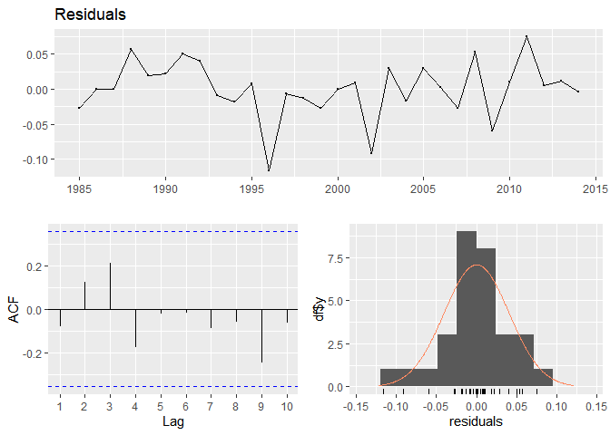

Figure 79

```
##
##  Breusch-Godfrey test for serial correlation of order up to 8
##
## data:  Residuals
## LM test = 4.2148, df = 8, p-value = 0.8372
```

```r
checkresiduals(model5.1)
```

```r
shapiro.test(residuals(model5.1))
```

```
##
##  Shapiro-Wilk normality test
##
## data:  residuals(model5.1)
## W = 0.93435, p-value = 0.06415
```

```r
VIF.model5.1<-vif(model5.1)
VIF.model5.1
```

```
## L(Y.t, k = 1)         P.t.1           P.t    trend(Y.t)
##      1.652871      1.217799      1.134044      1.628151
```

```r
VIF.model5.1>10
```

```
## L(Y.t, k = 1)         P.t.1           P.t    trend(Y.t)
##         FALSE         FALSE         FALSE         FALSE
```

In the output shown above, which is the test for multicollinearity by using the variance inflation factors (VIF) using the vif function, we can observe that there no issue with multicollinearity as VIF values are all less than 10.

## 3.8.0 Model Comparison and Selection

With our models selected from each section, we will now compare each models and select the best for further analysis in terms of its mase values.

```r
rbo.models<-c("model1.1","model2.2","model3.4","model4.4.3")
rbo.mase<-MASE(model1.1,model2.2,model3.4,model4.4.3)
rbo.mase<-rbo.mase[,-1]
rbo.mase2<-c("model5.1",accuracy(model5.1)[,6])
rbo.comp<-data.frame(rbo.models,rbo.mase)
rbo.comp<-rbind(rbo.comp,rbo.mase2)
rownames(rbo.comp)<-NULL
colnames(rbo.comp)<-c("Model","MASE")
arrange(rbo.comp,MASE)
```

```
##        Model              MASE
## 1   model1.1 0.523527046479962
## 2   model2.2 0.645180426887817
## 3   model5.1 0.654888310187682
## 4 model4.4.3 0.714569812384021
## 5   model3.4 0.840013507894619
```

Based on the lowest MASE values, we can now choose `model1.1` and `model2.2` for further analysis in the next section.

## 3.9.0 Forecasting

We will first forecast the data for `model1.1` which is a finite DLM with temperature predictor. Here we will also use the covariate values provided for point forecasting.

```r
rbo.covar[,2]
```

```
## # A tibble: 4 × 1
##   Temperature
##         <dbl>
## 1        20.7
## 2        20.5
## 3        20.5
## 4        20.6
```

```r
frc.model1.1<-forecast(model=model1.1,
                       x=c(20.74,20.49,20.52,20.56),
                       h=3)$forecast
frc.model1.1
```

```
## [1] 0.7323402 0.7106262 0.7145942
```

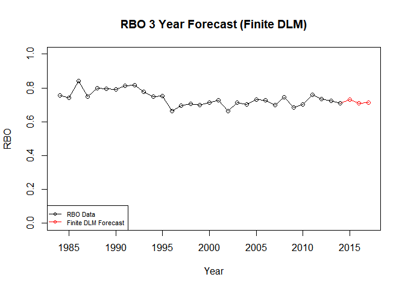

Figure 80

```r
y.extended<-c(rbo$RBO,frc.model1.1)
plot(ts(y.extended,start=1984),type="o",col="red",ylim=c(0,1),
     xlab="Year",ylab="RBO",main="RBO 3 Year Forecast (Finite DLM)")
lines(ts(as.vector(rbo$RBO),start=1984),col="black",type="o")
legend("bottomleft",lty=1,pch=1,cex=0.7,col=c("black","red"),
       c("RBO Data","Finite DLM Forecast"))
```

From `Figure 80` above, we can see that finite dlm fit and the plots for the next three years prediction (2015-2017). Next we will forecast the data for `model2.2` which is a Polynomial DLM with rainfall as a predictor.

```r
rbo.covar[,3]
```

```
## # A tibble: 4 × 1
##   Rainfall
##      <dbl>
## 1     2.27
## 2     2.38
## 3     2.26
## 4     2.27
```

```r
frc.model2.2<-forecast(model=model2.2,
                       x=c(20.74,20.49,20.52,20.56),
                       h=3,
                       interval=TRUE)$forecast
frc.model2.2
```

```
##       Lower Estimate    Upper
## 1 0.9519286 1.002706 1.052334
## 2 1.1166659 1.171438 1.218347
## 3 1.1999095 1.254158 1.305560
```

In the forecast output above, we can see the 95% lower bound, point forecast and 95% upper bound forecast data for RBO. We will now plot the model against the original data.

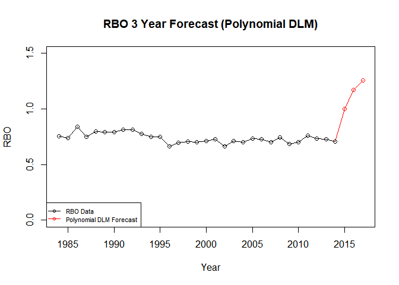

Figure 81

```r
y.extended2<-c(rbo$RBO,frc.model2.2$Estimate)
plot(ts(y.extended2,start=1984),type="o",col="red",ylim=c(0,1.5),
     xlab="Year",ylab="RBO",main="RBO 3 Year Forecast (Polynomial DLM)")
lines(ts(as.vector(rbo$RBO),start=1984),col="black",type="o")
legend("bottomleft",lty=1,pch=1,cex=0.7,col=c("black","red"),
       c("RBO Data","Polynomial DLM Forecast"))
```

## 3.10.0 Conclusion

From the previous sections, we have analyzed that the best models to forecast the next three years of RBO values are Finite Distributed Lag Model with temperature as a predictor for the data. With our forecast plots, we can conclude that Finite DLM predictor plot is more stable compared to the Polynomial DLM plot.

# 4.0.0 Task 3 (B)

## 4.1.0 Dynamic Lag Model Modelling

We will now perform a dynamic lag modelling using the `dynlm` package to obtain the 3 year ahead forecasts for droughts in consideration. Since there are 13 years of droughts from 1996-2009, we shall input T=13 as an argument in the model.

```r
Y.t=log(rbo.rbo.ts)
T=13
P.t=1*(seq(rbo.rbo.ts)==T)
P.t.1=Lag(P.t,+1)

dro.model1.1 = dynlm(Y.t ~ L(Y.t , k = 1 ) + P.t.1 + P.t + trend(Y.t))
dro.model1.2 = dynlm(Y.t ~ L(Y.t , k = 1 ) + P.t.1 + P.t + L(Y.t , k = 2 )
                 + trend(Y.t))

model.mase<-MASE(lm(dro.model1.1),lm(dro.model1.2))
arrange(model.mase,MASE)
```

```
##                   n      MASE
## lm(dro.model1.2) 29 0.6793374
## lm(dro.model1.1) 30 0.6982148
```

From the output above we can see that `dro.model1.2` contains the lowest MASE values hence we will select this model for further analysis.

```r
summary(dro.model1.2)
```

```
##
## Time series regression with "ts" data:
## Start = 1986, End = 2014
##
## Call:
## dynlm(formula = Y.t ~ L(Y.t, k = 1) + P.t.1 + P.t + L(Y.t, k = 2) +
##     trend(Y.t))
##
## Residuals:
##       Min        1Q    Median        3Q       Max
## -0.092874 -0.017957 -0.000999  0.019701  0.083729
##
## Coefficients:
##                Estimate Std. Error t value Pr(>|t|)
## (Intercept)   -0.115797   0.047982  -2.413  0.02417 *
## L(Y.t, k = 1)  0.133342   0.185797   0.718  0.48018
## P.t.1         -0.064887   0.047607  -1.363  0.18609
## P.t           -0.126084   0.041910  -3.008  0.00626 **
## L(Y.t, k = 2)  0.319041   0.167720   1.902  0.06974 .
## trend(Y.t)    -0.002749   0.001213  -2.267  0.03312 *
## ---
## Signif. codes:  0 '***' 0.001 '**' 0.01 '*' 0.05 '.' 0.1 ' ' 1
##
## Residual standard error: 0.04097 on 23 degrees of freedom
## Multiple R-squared:  0.6372, Adjusted R-squared:  0.5583
## F-statistic: 8.079 on 5 and 23 DF,  p-value: 0.0001609
```

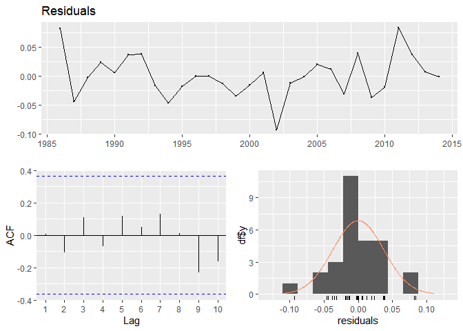

Figure 82

```
##
##  Breusch-Godfrey test for serial correlation of order up to 9
##
## data:  Residuals
## LM test = 13.672, df = 9, p-value = 0.1345
```

```r
checkresiduals(dro.model1.2)
```

```r
shapiro.test(residuals(dro.model1.2))
```

```
##
##  Shapiro-Wilk normality test
##
## data:  residuals(dro.model1.2)
## W = 0.96303, p-value = 0.3895
```

```r
dro.VIF.model<-vif(dro.model1.2)
dro.VIF.model
```

```
## L(Y.t, k = 1)         P.t.1           P.t L(Y.t, k = 2)    trend(Y.t)
##      2.159735      1.303569      1.010226      1.764767      1.777855
```

```r
dro.VIF.model>10
```

```
## L(Y.t, k = 1)         P.t.1           P.t L(Y.t, k = 2)    trend(Y.t)
##         FALSE         FALSE         FALSE         FALSE         FALSE
```

In the output shown above, which is the test for multicollinearity by using the variance inflation factors (VIF) using the vif function, we can observe that there no issue with multicollinearity as VIF values are all less than 10.